# Statistics Intro Problem 1

198fan

10/23/2021

## Problem 1

First, let’s read the csv file! (Somehow need to set encoding to Latin-1)

```r
clinical_study <- read.csv("clinical_study.csv", encoding = "Latin-1")
```

Let’s see some of its data! (Only showing importants part)

| 患者番号 | 投与群 | 性 | 年齢 | 降圧度 | 血圧.収縮期.0週. | 血圧.収縮期.12週. | 血圧.拡張期.0週. | 血圧.拡張期.12週. |
| --- | --- | --- | --- | --- | --- | --- | --- | --- |
| 1 | 被験薬 | 男性 | 58 | 下降 | 172 | 138 | 98 | 76 |
| 2 | 被験薬 | 男性 | 55 | やや下降 | 182 | 170 | 120 | 110 |
| 3 | 対照薬 | 女性 | 69 | 下降 | 208 | 160 | 108 | 80 |

First, to interpret this data, that is to know the relationship of the test drug(被験薬) in lowering blood pressure in both systolic period(収縮期) and diastolic period(拡張期), we need get numeric data, that is to calculate difference between week 0 and week 12.

| 患者番号 | 投与群 | 性 | 年齢 | 降圧度 | 収縮期の降圧 | 拡張期の降圧 |
| --- | --- | --- | --- | --- | --- | --- |
| 1 | 被験薬 | 男性 | 58 | 下降 | -34 | -22 |
| 2 | 被験薬 | 男性 | 55 | やや下降 | -12 | -10 |
| 3 | 対照薬 | 女性 | 69 | 下降 | -48 | -28 |

Now, we make two data.frame consisting of test drug(被験薬) group and reference drug(対照薬) group, after that proceed to make a general comparison using barplot.

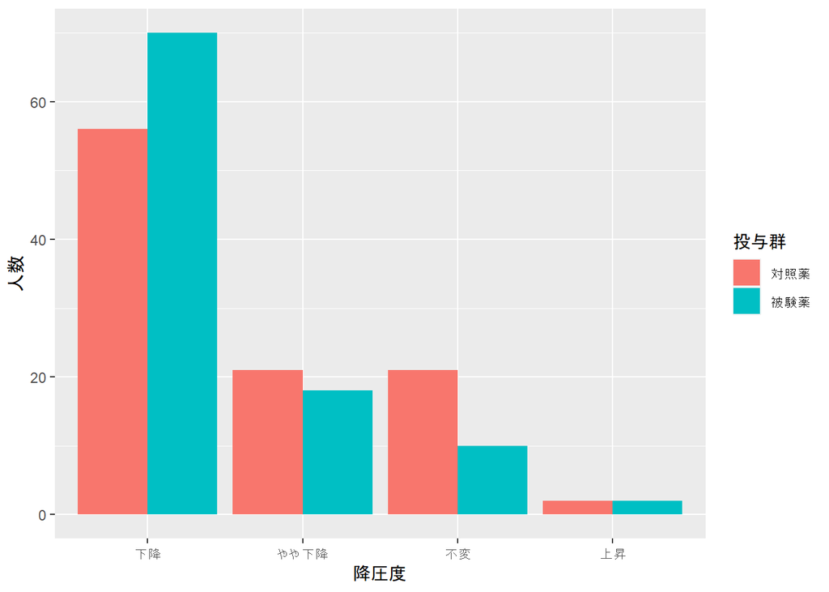

```r
library(ggplot2)
降圧度 <- rep(unique(useful_clinic$降圧度), each = 2)
投与群 <- rep(c("対照薬", "被験薬"), 4)
人数 <- c(length(ref_drug$降圧度[ref_drug$降圧度=="下降"]),
         length(test_drug$降圧度[test_drug$降圧度=="下降"]),
         length(ref_drug$降圧度[ref_drug$降圧度=="やや下降"]),
         length(test_drug$降圧度[test_drug$降圧度=="やや下降"]),
         length(ref_drug$降圧度[ref_drug$降圧度=="不変"]),
         length(test_drug$降圧度[test_drug$降圧度=="不変"]),
         length(ref_drug$降圧度[ref_drug$降圧度=="上昇"]),
         length(test_drug$降圧度[test_drug$降圧度=="上昇"]))
bar_clinic <- data.frame(降圧度, 投与群, 人数)
bar_clinic$降圧度 <- factor(bar_clinic$降圧度, levels = c("下降", "やや下降", "不変", "上昇"))

ggplot(bar_clinic, aes(fill=投与群, y=人数, x=降圧度)) +
    geom_bar(position="dodge", stat="identity")
```

From here, it is not clear that the test drug is that the test drug is effective even though, there is a difference in sum of people that have decreased blood pressure, since categorical data mask quite a lot of information, we can do hypothesis testing with the numerical data instead using t-test on both systole and diastol period.

Assumption: 1. Both data is independent 2. Both data follows normal distribution

systole (Test and Reference)

```
##
##  Shapiro-Wilk normality test
##
## data:  収縮期の降圧
## W = 0.99071, p-value = 0.7221
```

```
##
##  Shapiro-Wilk normality test
##
## data:  収縮期の降圧
## W = 0.98359, p-value = 0.2503
```

diastole (Test and Reference)

```
##
##  Shapiro-Wilk normality test
##
## data:  拡張期の降圧
## W = 0.98066, p-value = 0.1496
```

```
##
##  Shapiro-Wilk normality test
##
## data:  拡張期の降圧
## W = 0.97888, p-value = 0.1088
```

3. Both has the same variance systole (Test and Reference)

```
##
##  F test to compare two variances
##
## data:  test_drug$収縮期の降圧 and ref_drug$収縮期の降圧
## F = 1.1115, num df = 99, denom df = 99, p-value = 0.6001
## alternative hypothesis: true ratio of variances is not equal to 1
## 95 percent confidence interval:
##  0.7478353 1.6518865
## sample estimates:
## ratio of variances
##           1.111458
```

diastole (Test and Reference)

```
##
##  F test to compare two variances
##
## data:  test_drug$拡張期の降圧 and ref_drug$拡張期の降圧
## F = 1.1223, num df = 99, denom df = 99, p-value = 0.567
## alternative hypothesis: true ratio of variances is not equal to 1
## 95 percent confidence interval:
##  0.7551444 1.6680316
## sample estimates:
## ratio of variances
##           1.122321
```

```r
systol_test <- t.test(test_drug$収縮期の降圧, ref_drug$収縮期の降圧, alternative = "less")
systol_test
```

```
##
##  Welch Two Sample t-test
##
## data:  test_drug$収縮期の降圧 and ref_drug$収縮期の降圧
## t = -2.4699, df = 197.45, p-value = 0.007183
## alternative hypothesis: true difference in means is less than 0
## 95 percent confidence interval:
##       -Inf -1.982028
## sample estimates:
## mean of x mean of y
##    -26.39    -20.40
```

```r
diastol_test <- t.test(test_drug$拡張期の降圧, ref_drug$拡張期の降圧, alternative = "less")
diastol_test
```

```
##
##  Welch Two Sample t-test
##
## data:  test_drug$拡張期の降圧 and ref_drug$拡張期の降圧
## t = -1.6578, df = 197.34, p-value = 0.04947
## alternative hypothesis: true difference in means is less than 0
## 95 percent confidence interval:
##         -Inf -0.00738896
## sample estimates:
## mean of x mean of y
##    -13.60    -11.26
```

**Both the systol and diastol period p value is less that $\alpha = 0.05$, so we can say that the test drug is more effective than reference drug**

## Problem 2

First lets read the data!

```r
sushi <- read.csv("sushi.csv", encoding = "Latin-1")
```

Let’s see some of its data!

| ID | 商品 | 評価 |
| --- | --- | --- |
| 1 | 新商品 | 不味い |
| 2 | 新商品 | やや美味しい |
| 3 | 新商品 | やや美味しい |
| 4 | 新商品 | やや美味しい |
| 5 | 新商品 | やや美味しい |
| 6 | 新商品 | 美味しい |

After that, let’s make a barplot and a table of 新商品 and 既存品

Barplot

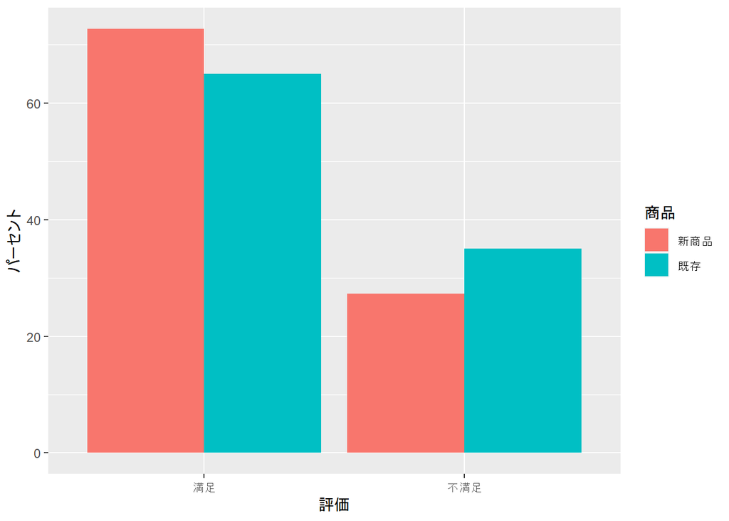

```r
library(ggplot2)
評価 <- c("満足", "満足", "不満足", "不満足")
商品 <- rep(c("新商品", "既存"), 2)
パーセント <- c(new_like/(new_like+new_dislike), old_like/(old_like+old_dislike), new_dislike/(new_like+new_dislike), old_dislike/(old_like+old_dislike)) * 100
bar_sushi <- data.frame(評価, 商品, パーセント)

ggplot(bar_sushi, aes(fill=商品, y=パーセント, x=評価)) +
    geom_bar(position="dodge", stat="identity")
```

Table

|  | 新商品 | 既存 |
| --- | --- | --- |
| 満足 | 280 | 247 |
| 不満足 | 105 | 133 |

Now we test independence using chi square test

```r
chisq.test(table_sushi)
```

```
##
##  Pearson's Chi-squared test with Yates' continuity correction
##
## data:  table_sushi
## X-squared = 4.9736, df = 1, p-value = 0.02574
```

**From the result, since p-value is less than $\alpha = 0.05$, we can conclude that there is some dependency between two categorical variable**